# Time Series Analysis: Modelling the Periodic Component of Monthly Data using Fourier Series Harmonic Analysis in RStudio

ORVILLE D. HOMBREBUENO

# Time Series Analysis

Time series data comes in many forms. It can be yearly, quarterly, monthly, daily and even hourly data. It can be heart rates at a given interval, it can be daily stock closing and opening prices, it can be hourly precipitation and temperature, it can be yearly population, etc. It’s not a surprise, in the 4th industrial revolution, time series data is available in almost all fields. Time series analysis is performed to gain insights – periodic and trend behavior – that will serve as basis for decision making. Imagine if farmers know the periodic behavior of rainfall. They will know what to plant, and when to plant it. Imagine if heavy rainfall can be predicted, disasters caused by floods can be minimized. Time series analysis can be very powerful and useful.

The main features of many time series are trends and seasonal variations that can be modelled deterministically with mathematical functions of time.

A given time series with respect to time $y(t)$ can be decomposed into the sum of its periodic component $P_{t}$, its trend component $T_{t}$, and random component $\epsilon_{t}$:

$$\begin{equation}
y(t)=P_{t}+T_{t}+\epsilon_{t}.
\end{equation}$$

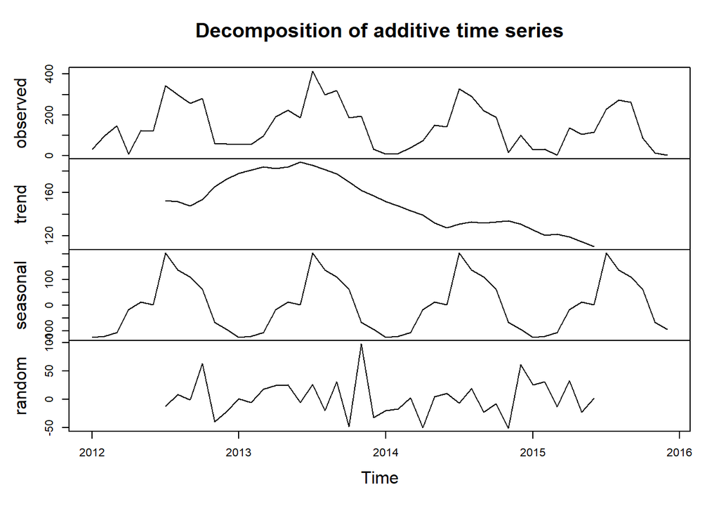

```r
load("~/R/R Projects/Rain Project/fmsmTS/Data/fmsmrdata1215.RData")
plot(decompose(fmsmrdata1215))
```

# Fourier Series

$$\begin{equation}
f(x)=\frac{a_{0}}{2}+\sum_{n=1}^{\infty} a_{n} \cos n x+\sum_{n=1}^{\infty} b_{n} \sin n x
\end{equation}$$

$$\begin{equation}
\begin{aligned}
&a_{0}=\frac{1}{\pi} \int_{-\pi}^{\pi} f(x) \mathrm{d} x\\
&a_{n}=\frac{1}{\pi} \int_{-\pi}^{\pi} f(x) \cos n x \mathrm{d} x \quad n=1,2, \ldots\\
&b_{n}=\frac{1}{\pi} \int_{-\pi}^{\pi} f(x) \sin n x \mathrm{d} x \quad n=1,2, \ldots
\end{aligned}
\end{equation}$$

# Fourier Series Harmonic Analysis

A function $f(x)$ of period $2L$ is repeated when $x$ increases by $2L$, i.e.

$$\begin{equation}
f(x+2L)=f(x)
\end{equation}$$

If we put $z=\frac{\pi}{L} x$, then the new function $f(z)$ is a periodic function of period $2\pi$. As $x$ increases from $-L$ to $L$, $z$ increases from $-\pi$ to $\pi$. We have

$$\begin{equation}
f(z)=\frac{a_{0}}{2}+\sum_{n=1}^{\infty} (a_{n} \cos n z + b_{n} \sin n z)
\end{equation}$$

$$\begin{equation}
f(t)=\frac{a_{0}}{2}+\sum_{n=1}^{\infty}\left(a_{n} \cos \frac{n \pi}{L} t+b_{n} \sin \frac{n \pi}{L} t\right)
\end{equation}$$

$$\begin{equation}
\begin{aligned}
&a_{0}=\frac{1}{L} \int_{-L}^{L} f(t) \mathrm{d} t\\
&a_{n}=\frac{1}{L} \int_{-L}^{L} f(t) \cos \frac{n \pi}{L} t \mathrm{d} t \quad n=1,2 \ldots\\
&b_{n}=\frac{1}{L} \int_{-L}^{L} f(t) \sin \frac{n \pi}{L} t \mathrm{d} t \quad n=1,2 \ldots
\end{aligned}
\end{equation}$$

# Bibliography

RStudio Team. (2019). *RStudio: Integrated development environment for r*. Boston, MA: RStudio, Inc. Retrieved from http://www.rstudio.com/

Weltner, K., John, S., Weber, W. J., Schuster, P., & Grosjean, J. (2014). *Mathematics for physicist and engineers: Fundamentals and interactive study guide* (2nd ed.). Springer-Verlag Heidelberg.